# Random R Codes Part-3

2014-12-31

R is now a large community. Today we have 4,567 6,139 R packages. My attempt here is to jot down the code snippets based on the newer packages (by following [table of available packages, sorted by date of publication](http://cran.r-project.org/web/packages/available_packages_by_date.html))[^1].

The chunk of the codes will be taken either from the Vignette or from the main package documentation pdf. I also like to include [stack overflow threads](http://stackoverflow.com/questions/tagged/r) if there are interesting questions. These interesting and easy-to-apply codes will be applied to different data sets to develop models and assumptions. In this random version, exploration on `rmarkdown` is done.

[figure not shown]

### Few Markdown Tips

[R Markdown Reference Guide](http://rmarkdown.rstudio.com/RMarkdownReferenceGuide.pdf) is a good source in learning `rmarkdown`. A must read.

#### Output Style

```
highlight= "default", "tango", "pygments", "kate", "monochrome", "espresso", "zenburn", "haddock", and "textmate"
theme= "default", "cerulean", "journal", "flatly", "readable", "spacelab", "united", and "cosmo"


output:
    html_document:
        toc: true
        toc_depth: 4
        theme: cerulean
        highlight: zenburn
```

#### Tables

```
| Item | Nuts and Bolts          |
| ------------- | ----------- |
| Why      | ~~Don't~~ why me|
| Dude     | _Don't_ dude me, Bro.    |

| Left-Aligned  | Center Aligned  | Right Aligned |
| :------------ |:---------------:| -----:|
| Left is a      | Center is not | Right is a |
| Left is a      | always        |   Right. Right is not |
| Left is a Left | centered        |   a `right`|
```

| Item | Nuts and Bolts |
| --- | --- |
| Why | Don’t why me |
| Dude | *Don’t* dude me, Bro. |

| Left-Aligned | Center Aligned | Right Aligned |
| --- | --- | --- |
| Left is a | Center is not | Right is a |
| Left is a | always | Right. Right is not |
| Left is a Left | centered | a `right` |

[output not shown]

Ordinal indicators are sometimes written as superscripts (1<sup>st</sup>, 2<sup>nd</sup>, 3<sup>rd</sup>, 4<sup>th</sup>, rather than 1st, 2nd, 3rd, 4th), although many English-language style guides recommend against this use. Other languages use a similar convention, such as 1<sup>er</sup> or 2<sup>e</sup> in French, or 4ª and 4º in Italian, Portuguese, and Spanish.

Also in mathematics and computing, a subscript can be used to represent the radix, or base, of a written number, especially where multiple bases are used alongside each other. For example, comparing values in hexadecimal, denary, and octal one might write C<sub>hex</sub> = 12<sub>dec</sub> = 14<sub>oct</sub>.

#### Equation

```
$$
\begin{aligned}
\dot{x} & = \sigma(y-x) \\
\dot{y} & = \rho x - y - xz \\
\dot{z} & = -\beta z + xy
\end{aligned}
$$
```

$\begin{aligned} \dot{x} & = \sigma(y-x) \\ \dot{y} & = \rho x - y - xz \\ \dot{z} & = -\beta z + xy \end{aligned}$

### Multiple Correspondence Analysis (MCA)

**Five** R packages are widely used for `Multiple Correspondence Analysis (MCA)`. **Part 3** compiles MCA codes.

[figure not shown]

The packages are:

> Factominer, MASS, ade4, ca, homals

> I have used the codes compiled by [Gaston Sanchez](http://gastonsanchez.com/blog/how-to/2012/10/13/MCA-in-R.html)

#### FactoMineR

```r
library(FactoMineR)
library(ggplot2)

data(tea)
newtea = tea[, c("Tea", "How", "how", "sugar", "where", "always")]
head(newtea, 3)
```

```
##         Tea   How     how    sugar       where     always
## 1     black alone tea bag    sugar chain store Not.always
## 2     black  milk tea bag No.sugar chain store Not.always
## 3 Earl Grey alone tea bag No.sugar chain store Not.always
```

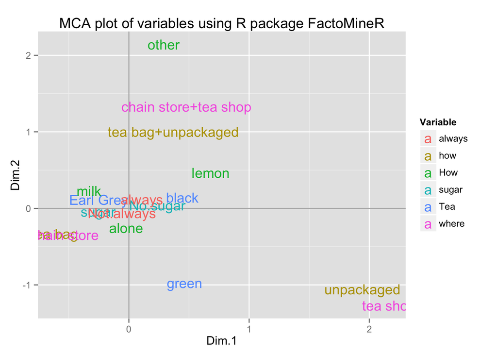

```r
cats = apply(newtea, 2, function(x) nlevels(as.factor(x)))
mca1 = MCA(newtea, graph = FALSE)
mca1_vars_df = data.frame(mca1$var$coord, Variable = rep(names(cats), cats))
mca1_obs_df = data.frame(mca1$ind$coord)
ggplot(data=mca1_vars_df, aes(x = Dim.1, y = Dim.2, label = rownames(mca1_vars_df))) +
 geom_hline(yintercept = 0, colour = "gray70") +
 geom_vline(xintercept = 0, colour = "gray70") +
 geom_text(aes(colour=Variable)) +
 ggtitle("MCA plot of variables using R package FactoMineR")
```

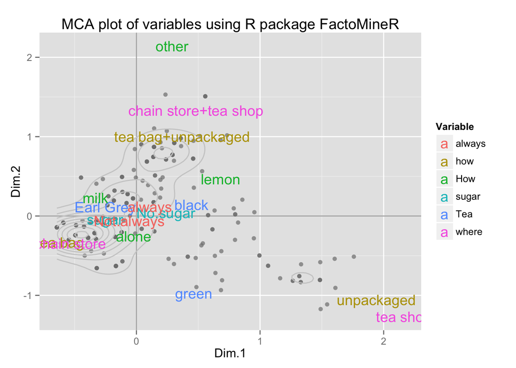

```r
ggplot(data = mca1_obs_df, aes(x = Dim.1, y = Dim.2)) +
  geom_hline(yintercept = 0, colour = "gray70") +
  geom_vline(xintercept = 0, colour = "gray70") +
  geom_point(colour = "gray50", alpha = 0.7) +
  geom_density2d(colour = "gray80") +
  geom_text(data = mca1_vars_df, aes(x = Dim.1, y = Dim.2,
                label = rownames(mca1_vars_df), colour = Variable)) +
  ggtitle("MCA plot of variables using R package FactoMineR") +
  scale_colour_discrete(name = "Variable")
```

#### MASS

```r
library(MASS)
mca2 = mca(newtea, nf = 5)
mca2$d^2
```

```
## [1] 0.2797618 0.2577477 0.2201379 0.1879296 0.1687650
```

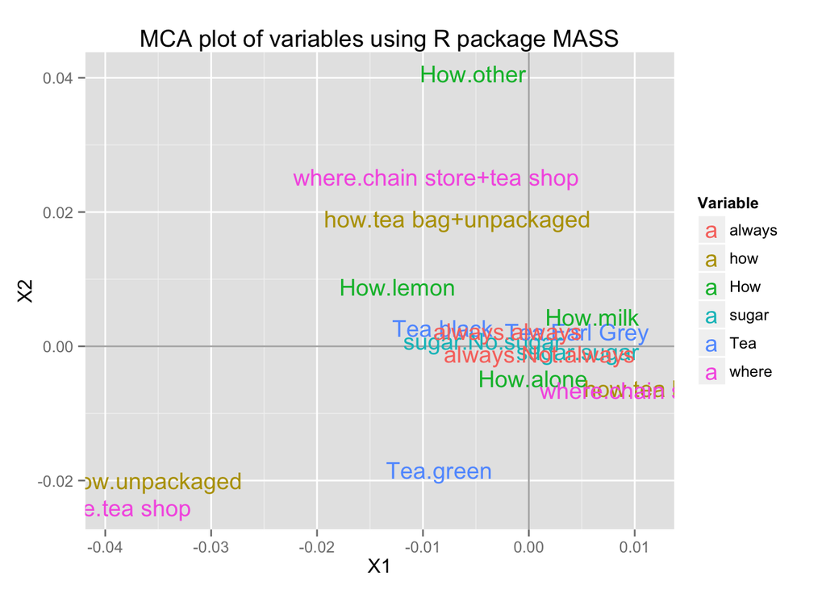

```r
mca2_vars_df = data.frame(mca2$cs, Variable = rep(names(cats), cats))
ggplot(data = mca2_vars_df,
       aes(x = X1, y = X2, label = rownames(mca2_vars_df))) +
  geom_hline(yintercept = 0, colour = "gray70") +
  geom_vline(xintercept = 0, colour = "gray70") +
  geom_text(aes(colour = Variable)) +
  ggtitle("MCA plot of variables using R package MASS")
```

#### ade4

```r
library(ade4)
mca3 = dudi.acm(newtea, scannf = FALSE, nf = 5)
mca3$eig
```

```
##  [1] 0.27976178 0.25774772 0.22013794 0.18792961 0.16876495 0.16368666
##  [7] 0.15288834 0.13838682 0.11569167 0.08612637 0.06221147
```

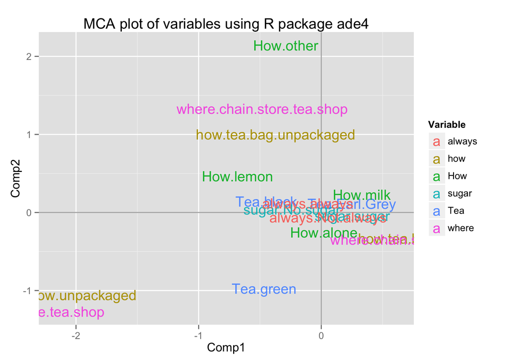

```r
mca3_vars_df = data.frame(mca3$co, Variable = rep(names(cats), cats))
ggplot(data = mca3_vars_df,
       aes(x = Comp1, y = Comp2, label = rownames(mca3_vars_df))) +
  geom_hline(yintercept = 0, colour = "gray70") +
  geom_vline(xintercept = 0, colour = "gray70") +
  geom_text(aes(colour = Variable)) +
  ggtitle("MCA plot of variables using R package ade4")
```

#### ca

```r
library(ca)
mca4 = mjca(newtea, lambda = "indicator", nd = 5)
mca4$sv^2
```

```
##  [1] 0.27976178 0.25774772 0.22013794 0.18792961 0.16876495 0.16368666
##  [7] 0.15288834 0.13838682 0.11569167 0.08612637 0.06221147
```

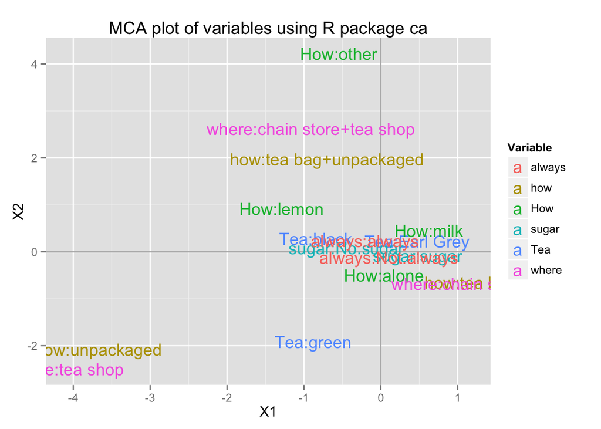

```r
mca4_vars_df = data.frame(mca4$colcoord, Variable = rep(names(cats), cats))
rownames(mca4_vars_df) = mca4$levelnames
ggplot(data = mca4_vars_df,
       aes(x = X1, y = X2, label = rownames(mca4_vars_df))) +
  geom_hline(yintercept = 0, colour = "gray70") +
  geom_vline(xintercept = 0, colour = "gray70") +
  geom_text(aes(colour = Variable)) +
  ggtitle("MCA plot of variables using R package ca")
```

#### homals

[output not shown]

[^1]: Compiled by [Subasish Das](http://subasish.tumblr.com)